# Requests

### The requests library is the de facto standard for making HTTP requests in Python. It abstracts the complexities of making requests behind a beautiful, simple API so that you can focus on interacting with services and consuming data in your application.

```python
import requests as req
# http://docs.python-requests.org/en/master/
```

## A simple get request

```python
url = 'http://localhost/index2.html'
```

```python
resp = req.get(url)
```

## status_code

Status code of the request

*200*: ok

*301*: redirect

*404*: not found

*500*: internal server error

```python
resp.status_code
```

```
200
```

## content

response returned in bytes format

```python
resp.content
```

```
b'<html>\r\n<head><title>Some title</title></head>\r\n<body>\r\nContent in body\r\n<body>\r\n</html>'
```

## text

response in text format according to encoding of the page

```python
resp.text
```

```
'<html>\r\n<head><title>Some title</title></head>\r\n<body>\r\nContent in body\r\n<body>\r\n</html>'
```

## headers

headers received from the server

Contains important info like:

• **Content-Type**: type of response eg. html, json, jpeg, etc.

• **Content-Length**: Size of the content in bytes

• **Last-Modified**: last modified date and time of the page requested

```python
dict(resp.headers)
```

```
{'Date': 'Fri, 22 Mar 2019 19:42:30 GMT',
 'Server': 'Apache/2.4.38 (Win64) OpenSSL/1.1.1b PHP/7.3.2',
 'Last-Modified': 'Fri, 22 Mar 2019 18:41:02 GMT',
 'ETag': '"58-584b3325ce668"',
 'Accept-Ranges': 'bytes',
 'Content-Length': '88',
 'Keep-Alive': 'timeout=5, max=100',
 'Connection': 'Keep-Alive',
 'Content-Type': 'text/html'}
```

```python
# Viewing an image
from PIL import Image
from io import BytesIO
```

```python
url = 'http://localhost/img_lights.jpg'
```

```python
resp = req.get(url)
```

```python
i = Image.open(BytesIO(resp.content))
```

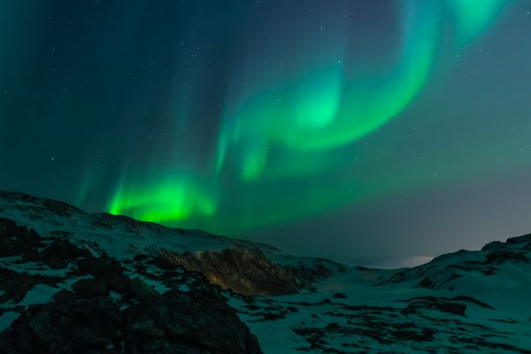

```python
i
```

# File downloading

Files which have a large size and whose data cannot be directly assigned to a variable and downloaded in parts.

Why? If the file is too large, the system may crash trying to load it into the RAM also known as **RAM leak**.

We use **iter_content** in the response object to work with such files. By iterating through a fixed portion of the file we thus avoid potential RAM leaks.

We can also use this loop to keep the user updated about the progress of the download.

```python
resp = req.get(url, stream=True)
```

```python
with open('file.jpeg', 'wb') as fd:
    for chunk in resp.iter_content(chunk_size=128):
        fd.write(chunk)
```

# GET request

GET request method retrieves information from the server. As part of a GET request, some data can be passed within the URL's query string, specifying (for example) search terms, date ranges, or other information that defines the query.

Used by all search engines to send the query string to its servers

```python
url = 'https://postman-echo.com/get'
```

```python
data = {'data': 'some data', 'status': 0}
```

```python
resp = req.get(url, data=data)
```

```python
resp.json()
```

```
{'args': {'data': 'some data', 'status': '0'},
 'headers': {'x-forwarded-proto': 'https',
  'host': 'postman-echo.com',
  'content-length': '23',
  'accept': '*/*',
  'accept-encoding': 'gzip, deflate',
  'content-type': 'application/x-www-form-urlencoded',
  'user-agent': 'python-requests/2.21.0',
  'x-forwarded-port': '443'},
 'url': 'https://postman-echo.com/get'}
```

```python
# getting json
```

# POST request

POST request method requests that a web server accepts the data enclosed in the body of the request message, most likely for storing it. It is often used when uploading a file or when submitting a completed web form.

Used for sending username/email and pssword details to the server.

```python
data = {'type': 'some type', 'status': 0}
```

```python
url = 'https://postman-echo.com/post'
```

```python
resp = req.post(url, data=data)
```

```python
resp.json()
```

```
{'args': {},
 'data': '',
 'files': {},
 'form': {'type': 'some type', 'status': '0'},
 'headers': {'x-forwarded-proto': 'https',
  'host': 'postman-echo.com',
  'content-length': '23',
  'accept': '*/*',
  'accept-encoding': 'gzip, deflate',
  'content-type': 'application/x-www-form-urlencoded',
  'user-agent': 'python-requests/2.21.0',
  'x-forwarded-port': '443'},
 'json': {'type': 'some type', 'status': '0'},
 'url': 'https://postman-echo.com/post'}
```

# Other methods of requestsing content from a server

## HEAD

The HEAD method asks for a response identical to that of a GET request, but without the response body. This is useful for retrieving meta-information written in response headers, without having to transport the entire content.

Uses:

• Querying for size of a file before downloading it.

• To check whether a file has changed

```python
url = 'https://google.com'
```

```python
resp = req.head(url)
```

```python
resp.content
```

```
b''
```

```python
dict(resp.headers)
```

```
{'Location': 'https://www.google.com/',
 'Content-Type': 'text/html; charset=UTF-8',
 'Date': 'Fri, 22 Mar 2019 19:48:46 GMT',
 'Expires': 'Sun, 21 Apr 2019 19:48:46 GMT',
 'Cache-Control': 'public, max-age=2592000',
 'Server': 'gws',
 'Content-Length': '220',
 'X-XSS-Protection': '1; mode=block',
 'X-Frame-Options': 'SAMEORIGIN',
 'Alt-Svc': 'quic=":443"; ma=2592000; v="46,44,43,39"'}
```

## PUT

The PUT method requests that the enclosed entity be stored under the supplied URI. If the URI refers to an already existing resource, it is modified; if the URI does not point to an existing resource, then the server can create the resource with that URI. *method support*

## DELETE

The DELETE method deletes the specified resource. *method support*

## OPTIONS

The OPTIONS method returns the HTTP methods that the server supports for the specified URL. *method support*

## PATCH

The PATCH method applies partial modifications to a resource. *method support*

## TRACE

The TRACE method echoes the received request so that a client can see what (if any) changes or additions have been made by intermediate servers.

## CONNECT

The CONNECT method converts the request connection to a transparent TCP/IP tunnel, usually to facilitate SSL-encrypted communication (HTTPS) through an unencrypted HTTP proxy.

## Error list

• '**RequestException'**

• 'ConnectTimeout'

• 'ConnectionError'

• 'HTTPError'

• 'ReadTimeout'

• 'Timeout'

• 'TooManyRedirects'

• 'URLRequired'